# CS01: Biomarkers of Recent Use

Derek, Eddie, Rainer

## Introduction

### Load packages

```r
library(tidymodels)
library(tidyverse)
library(dplyr)
library(ggplot2)
library(janitor)
library(purrr)
library(rstatix)
library(cowplot)
```

## Question

- Which compound, in which matrix, and at what cutoff is the best biomarker of recent use? (recent use is defined as 3h)
- “do some compound repsond more to high dose/low dose compared to the other?”

## The Data

### Data Import

```r
WB = read.csv("data/Blood.csv")
BR = read.csv("data/Breath.csv")
OF = read.csv("data/OF.csv")
```

### Data Wrangling

**Suggestion: add a new column recording whether someone should be determined to have recent THC use (THC group, within 3 hr of smoking) or not(all placebo group, or THC group outside the 3hr window)

```r
OF <- OF |>
  mutate(Treatment = fct_recode(Treatment,
                                "5.9% THC (low dose)" = "5.90%",
                                "13.4% THC (high dose)" = "13.40%"),
         Treatment = fct_relevel(Treatment, "Placebo", "5.9% THC (low dose)"),
         Group = fct_recode(Group,
                            "Occasional user" = "Not experienced user",
                            "Frequent user" = "Experienced user" )) |>
  janitor::clean_names() |>
  rename(thcoh = x11_oh_thc,
         thcv = thc_v)

WB <- WB |>
  mutate(Treatment = fct_recode(Treatment,
                                "5.9% THC (low dose)" = "5.90%",
                                "13.4% THC (high dose)" = "13.40%"),
         Treatment = fct_relevel(Treatment, "Placebo", "5.9% THC (low dose)")) |>
  janitor::clean_names() |>
  rename(fluid = fluid_type,
         thcoh = x11_oh_thc,
         thccooh = thc_cooh,
         thccooh_gluc = thc_cooh_gluc,
         thcv = thc_v)

BR <- BR |>
  mutate(Treatment = fct_recode(Treatment,
                                "5.9% THC (low dose)" = "5.90%",
                                "13.4% THC (high dose)" = "13.40%"),
         Treatment = fct_relevel(Treatment, "Placebo", "5.9% THC (low dose)"),
         Group = fct_recode(Group,
                            "Occasional user" = "Not experienced user",
                            "Frequent user" = "Experienced user" )) |>
  janitor::clean_names() |>
  rename(thc = thc_pg_pad)


compounds_WB <-  as.list(colnames(Filter(function(x) !all(is.na(x)), WB[6:13])))
compounds_BR <-  as.list(colnames(Filter(function(x) !all(is.na(x)), BR[6])))
compounds_OF <-  as.list(colnames(Filter(function(x) !all(is.na(x)), OF[6:12])))
```

Created 3 tables based on specific minutes and labeled accordingly, covering pre-smoking and subsequent post-smoking time periods for blood, breath, and oral fluid data.

```r
timepoints_WB <- tibble(
  start = c(-400, 0, 30, 70, 100, 180, 210, 240, 270, 300),
  stop = c(
    0,
    30,
    70,
    100,
    180,
    210,
    240,
    270,
    300,
    max(WB$time_from_start, na.rm = TRUE)
  ),
  timepoint = c(
    "pre-smoking",
    "0-30 min",
    "31-70 min",
    "71-100 min",
    "101-180 min",
    "181-210 min",
    "211-240 min",
    "241-270 min",
    "271-300 min",
    "301+ min"
  )
)

timepoints_BR <- tibble(
  start = c(-400, 0, 40, 90, 180, 210, 240, 270),
  stop = c(
    0,
    40,
    90,
    180,
    210,
    240,
    270,
    max(BR$time_from_start, na.rm = TRUE)
  ),
  timepoint = c(
    "pre-smoking",
    "0-40 min",
    "41-90 min",
    "91-180 min",
    "181-210 min",
    "211-240 min",
    "241-270 min",
    "271+ min"
  )
)

timepoints_OF <- tibble(
  start = c(-400, 0, 30, 90, 180, 210, 240, 270),
  stop = c(0, 30, 90, 180, 210, 240, 270,
           max(OF$time_from_start, na.rm = TRUE)),
  timepoint = c(
    "pre-smoking",
    "0-30 min",
    "31-90 min",
    "91-180 min",
    "181-210 min",
    "211-240 min",
    "241-270 min",
    "271+ min"
  )
)

assign_timepoint <- function(x, timepoints) {
  if (!is.na(x)) {
    timepoints$timepoint[x > timepoints$start & x <= timepoints$stop]
  } else{
    NA
  }
}
```

We created a new column, **`timepoint_use`**, in each table by mapping the **`time_from_start`** values to specific timepoints defined in separate reference data frames (**`timepoints_WB`**, **`timepoints_OF`**, **`timepoints_BR`**). Finally, releveled the **`timepoint_use`** factor variable to align with the order specified in the reference data frames. This ensures consistent and meaningful timepoint labels for subsequent analyses or visualizations in the study.

```r
 WB <- WB |>
  mutate(timepoint_use = map_chr(time_from_start,
                                 assign_timepoint,
                                 timepoints=timepoints_WB),
         timepoint_use = fct_relevel(timepoint_use, timepoints_WB$timepoint))

OF <- OF |>
  mutate(timepoint_use = map_chr(time_from_start,
                                 assign_timepoint,
                                 timepoints=timepoints_OF),
         timepoint_use = fct_relevel(timepoint_use, timepoints_OF$timepoint))

BR <- BR |>
  mutate(timepoint_use = map_chr(time_from_start,
                                 assign_timepoint,
                                 timepoints=timepoints_BR),
         timepoint_use = fct_relevel(timepoint_use, timepoints_BR$timepoint))
```

remove duplicate id

```r
WB <- drop_dups(WB)
OF <- drop_dups(OF)
BR <- drop_dups(BR)
```

### Exploratory Data Analysis

## compounds measurements over time

note: do we care about occasional/frequent user? might be more informative if coloured by placebo/non placedo

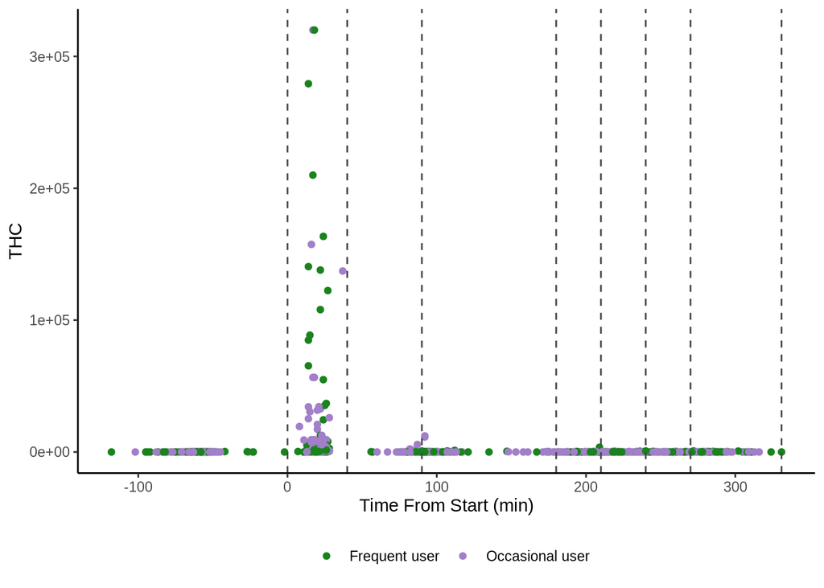

```r
scatter_wb <- map(compounds_BR, ~ compound_scatterplot_group(
    dataset=BR,
    compound=.x,
    timepoints=timepoints_BR))
```

calculating sensitivity and specificity

```r
output_WB <- map_dfr(compounds_WB,
                     ~sens_spec_cpd(dataset = WB, cpd = all_of(.x),
                                    timepoints = timepoints_WB)) |> clean_gluc()

output_BR <- map_dfr(compounds_BR,
                     ~sens_spec_cpd(dataset = BR,  cpd = all_of(.x),
                                    timepoints = timepoints_BR))  %>% clean_gluc()

output_OF <- map_dfr(compounds_OF,
                     ~sens_spec_cpd(dataset = OF, cpd = all_of(.x),
                                    timepoints = timepoints_OF))  %>% clean_gluc()
```

## cutoff vs. sensitivity/specificity

Here we plot the value of the cutoff against sensitivity and specificity for every compound in every matrix, and arrange them all into one big plot

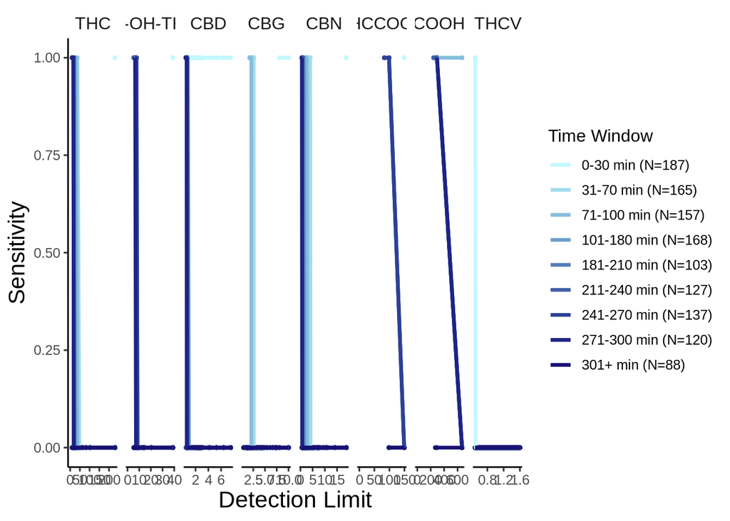

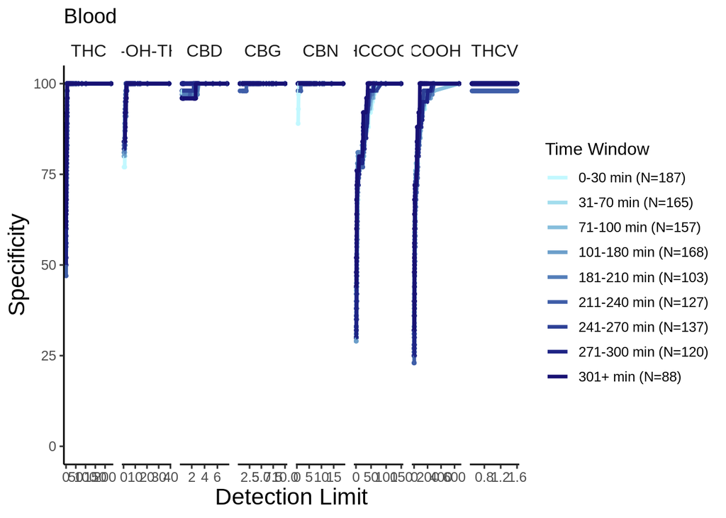

```r
#plot detection limit(cutoff) vs. sensitivity and specificity
ss_WB <- ss_plot(output_WB, tpts = length(unique(output_WB$time_start)), tissue = "Blood")
```

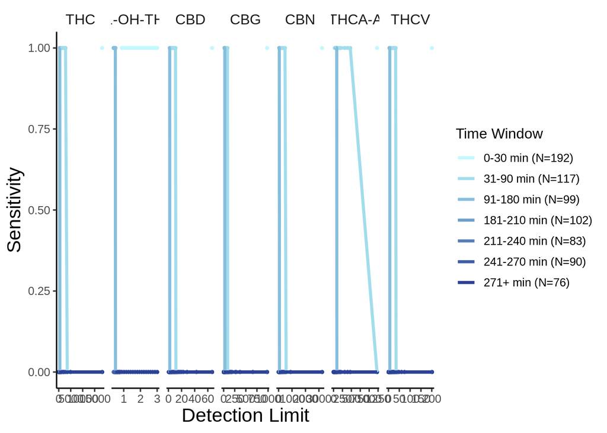

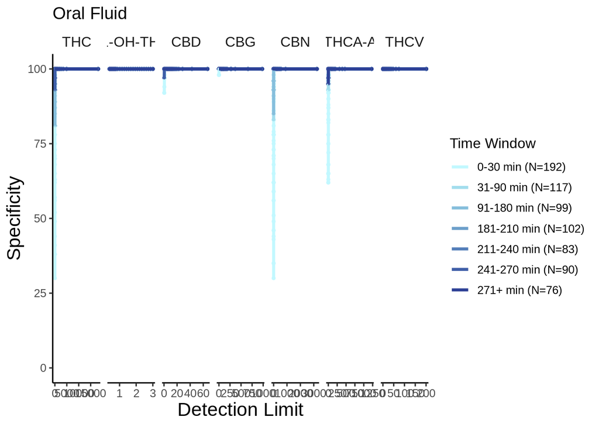

```r
ss_OF <- ss_plot(output_OF, tpts = length(unique(output_OF$time_start)), tissue = "Oral Fluid")
```

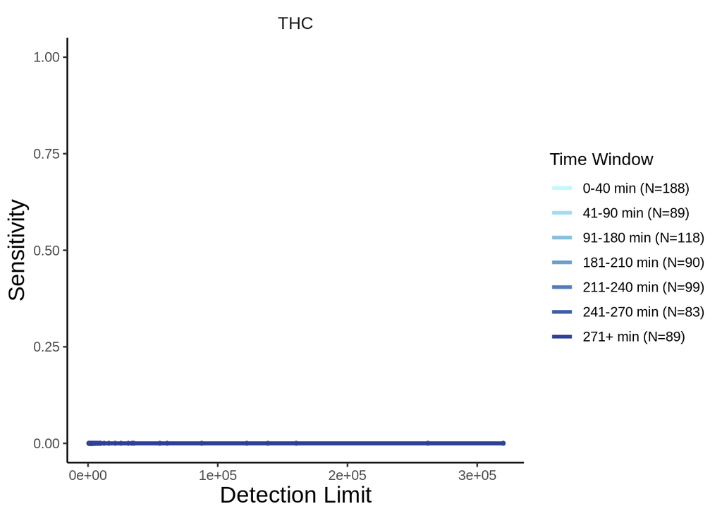

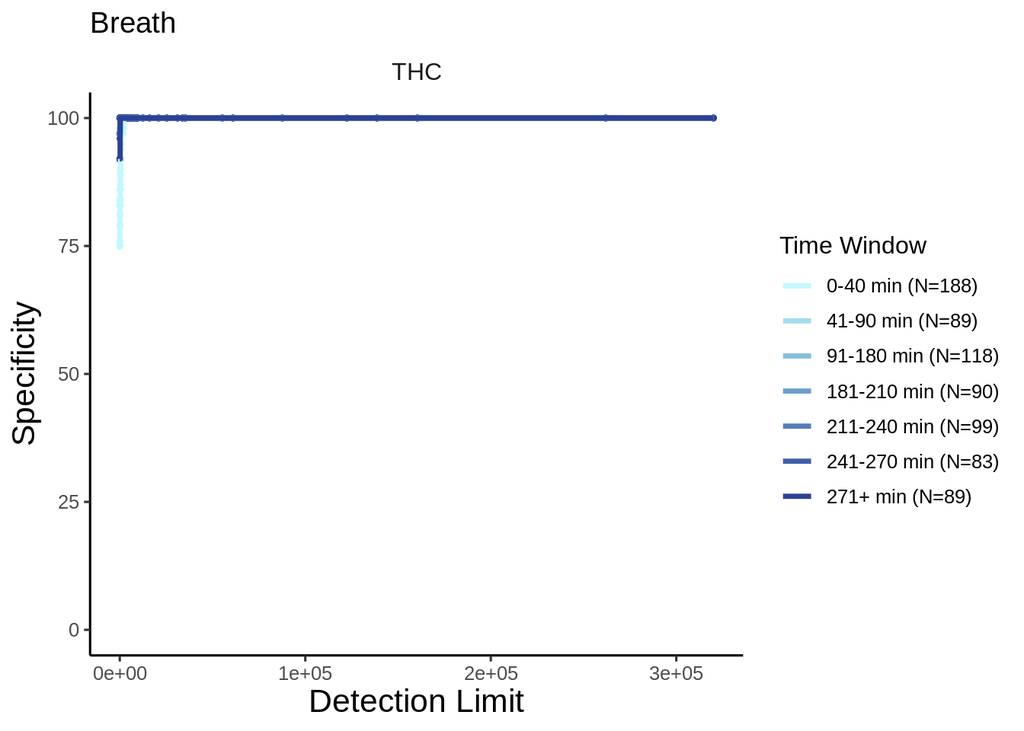

```r
ss_BR <- ss_plot(output_BR, tpts = length(unique(output_BR$time_start)), tissue = "Breath")
```

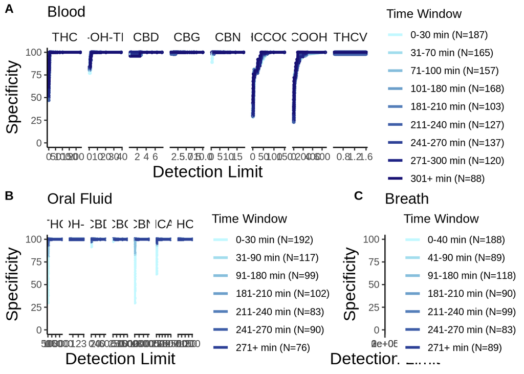

```r
#arranges ss plots into one
ss_bottom_row <- plot_grid(ss_OF, ss_BR, labels = c('B', 'C'), label_size = 12, ncol = 2, rel_widths = c(0.66, .33))
plot_grid(ss_WB, ss_bottom_row, labels = c('A', ''), label_size = 12, ncol = 1)
```

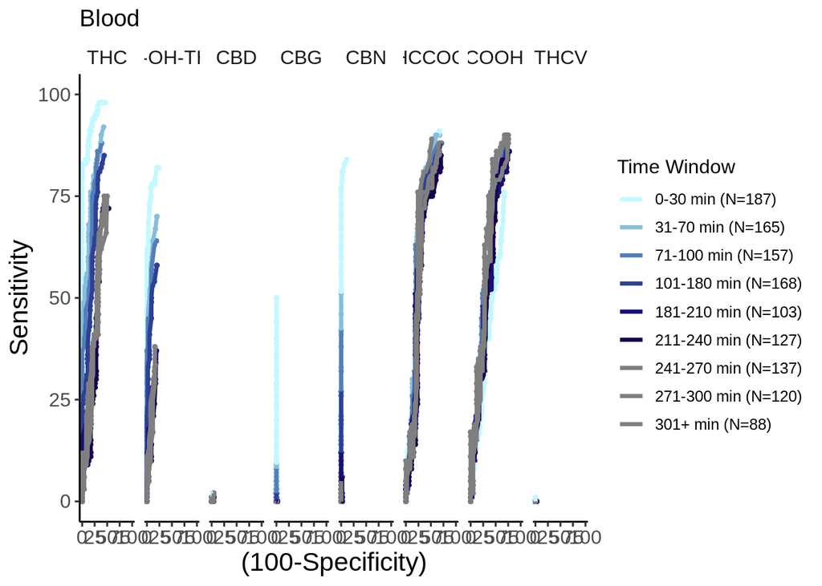

```r
#plot sensitivity vs. specificity
roc_WB = roc_plot(output_WB, tpts = length(unique(output_WB$time_start)), tissue = "Blood")
```

[figure not shown]

```r
roc_OF = roc_plot(output_WB, tpts = length(unique(output_WB$time_start)), tissue = "Oral Fluid")
```

[figure not shown]

```r
roc_BR = roc_plot(output_WB, tpts = length(unique(output_WB$time_start)), tissue = "Breath")
```

[figure not shown]

```r
#arrange roc plots
roc_bottom_row <- plot_grid(roc_OF, roc_BR, labels = c('B', 'C'), label_size = 12, ncol = 2, rel_widths = c(0.66, .33))
plot_grid(roc_WB, roc_bottom_row, labels = c('A', ''), label_size = 12, ncol = 1)
```

## plot sensitivity and speciticity over time given specific cutoffs

```r
#pass specific cutoff into splits parameter
WB_THC <- sens_spec_cpd(dataset = WB, cpd = 'thc',
                        timepoints = timepoints_WB,
                        splits =  c(0.5, 1, 2, 5, 10)) %>% clean_gluc()

WB_THC
```

```
## # A tibble: 50 × 17
##       TP    FN    FP    TN detection_limit compound time_start time_stop
##    <dbl> <dbl> <int> <int>           <dbl> <chr>         <dbl>     <dbl>
##  1     0     0    81   108             0.5 THC            -400         0
##  2     0     0    61   128             1   THC            -400         0
##  3     0     0    45   144             2   THC            -400         0
##  4     0     0    10   179             5   THC            -400         0
##  5     0     0     1   188            10   THC            -400         0
##  6   124     2    28    33             0.5 THC               0        30
##  7   123     3    22    39             1   THC               0        30
##  8   119     7    15    46             2   THC               0        30
##  9   106    20     4    57             5   THC               0        30
## 10   101    25     0    61            10   THC               0        30
## # ℹ 40 more rows
## # ℹ 9 more variables: time_window <chr>, NAs <int>, N <int>, N_removed <int>,
## #   Sensitivity <dbl>, Specificity <dbl>, PPV <dbl>, NPV <dbl>,
## #   Efficiency <dbl>
```

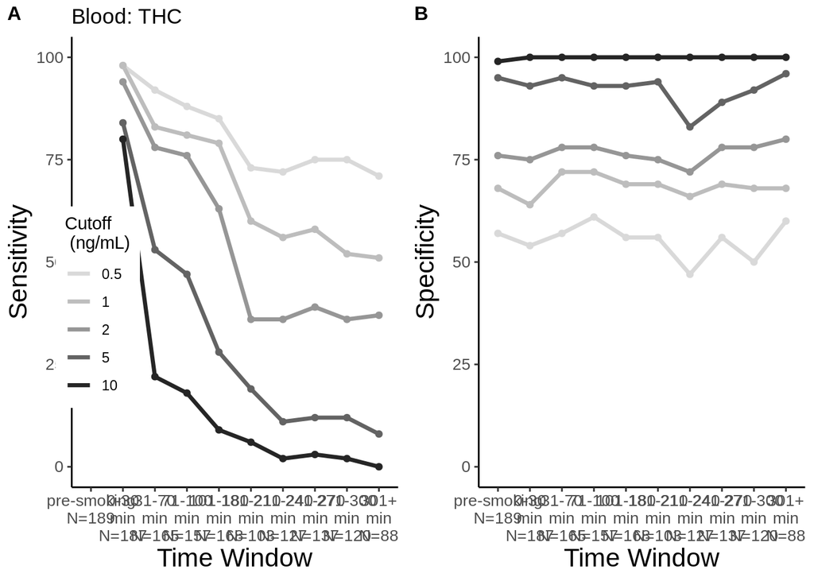

```
##
## [[2]]
## # A tibble: 50 × 18
##       TP    FN    FP    TN detection_limit compound time_start time_stop
##    <dbl> <dbl> <int> <int> <fct>           <chr>         <dbl>     <dbl>
##  1     0     0    81   108 0.5             THC            -400         0
##  2     0     0    61   128 1               THC            -400         0
##  3     0     0    45   144 2               THC            -400         0
##  4     0     0    10   179 5               THC            -400         0
##  5     0     0     1   188 10              THC            -400         0
##  6   124     2    28    33 0.5             THC               0        30
##  7   123     3    22    39 1               THC               0        30
##  8   119     7    15    46 2               THC               0        30
##  9   106    20     4    57 5               THC               0        30
## 10   101    25     0    61 10              THC               0        30
## # ℹ 40 more rows
## # ℹ 10 more variables: time_window <fct>, NAs <int>, N <int>, N_removed <int>,
## #   Sensitivity <dbl>, Specificity <dbl>, PPV <dbl>, NPV <dbl>,
## #   Efficiency <dbl>, my_label <fct>
```

```r
blood_levels <- c("pre-smoking\nN=189", "0-30\nmin\nN=187", "31-70\nmin\nN=165",
                  "71-100\nmin\nN=157", "101-180\nmin\nN=168", "181-210\nmin\nN=103",
                  "211-240\nmin\nN=127", "241-270\nmin\nN=137", "271-300\nmin\nN=120",
                  "301+\nmin\nN=88")
of_levels <- c("pre-smoking\nN=192", "0-30\nmin\nN=192", "31-90\nmin\nN=117",
               "91-180\nmin\nN=99", "181-210\nmin\nN=102", "211-240\nmin\nN=83",
               "241-270\nmin\nN=90",  "271+\nmin\nN=76")


plot_cutoffs(dataset=WB_THC,
             timepoint_use_variable=WB$timepoint_use,
             tissue="Blood",
             cpd="THC",
             x_labels=blood_levels)
```

## extended question

### wrangling

```r
WB_long = WB |>
  pivot_longer(6:13, names_to = "compound")

OF_long = OF |>
  pivot_longer(6:12, names_to = "compound")

BR_long <- BR |> pivot_longer(6)

df_full <- bind_rows(WB_long, OF_long, BR_long)
```

### Part 1: so uh the “placebo groups might have different compound measurements” hypothesis has been disproven :(

This one is me testing out an extended question our group proposed: does taking a placebo have an effect on any of the compound?

Theoretically, no, it shouldn’t. But the graph about subjective highness being basically random really peaked my interest and I thought there might be something worth looking into. But the data disproves that theory :(

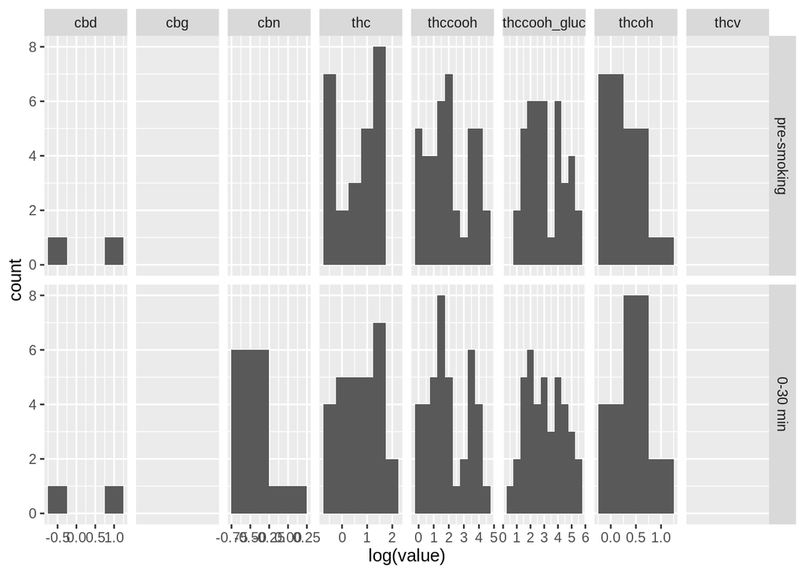

```r
WB_long|>
  filter(treatment == "Placebo") |>
  filter(timepoint_use == "pre-smoking" | timepoint_use == "0-30 min") |>
  ggplot(mapping = aes(x = log(value))) +
    geom_histogram(binwidth = 0.5) +
    facet_grid(vars(timepoint_use), vars(compound), scales = "free")
```

###part 2: BUT i have a different extended questgion we can look into

This one is SUPER interesting. Some of the pairplots we went over in lecture notes 12 looked like they has two separate lines, so I thought one of the variables might change how compounds correlate with each other - and they do! Namely, the low dose and high dose group seems to have different slopes when it comes to the correlation between certain compounds.

Here’s a few of the more obvious ones:

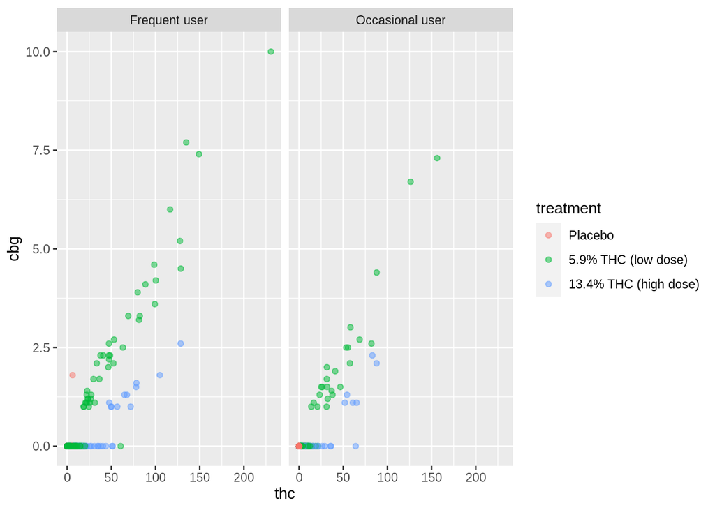

```r
ggplot(data = WB,
       aes(y = cbg, x = thc, color = treatment)) +
  geom_point(alpha = 0.5) +
  facet_wrap(~group)
```

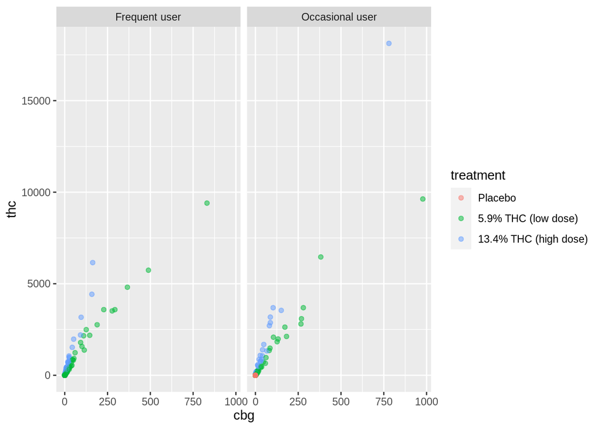

```r
ggplot(data = OF,
       aes(y = thc, x = cbg, color = treatment)) +
  geom_point(alpha = 0.5) +
  facet_wrap(~group)
```

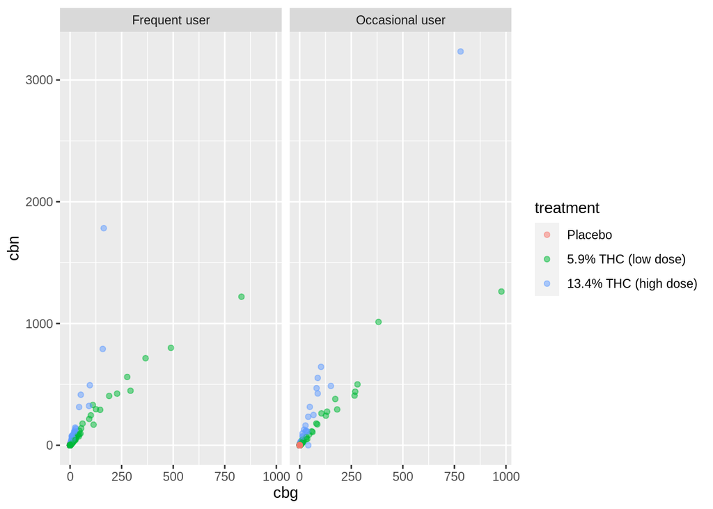

```r
ggplot(data = OF,
       aes(y = cbn, x = cbg, color = treatment)) +
  geom_point(alpha = 0.5) +
  facet_wrap(~group)
```

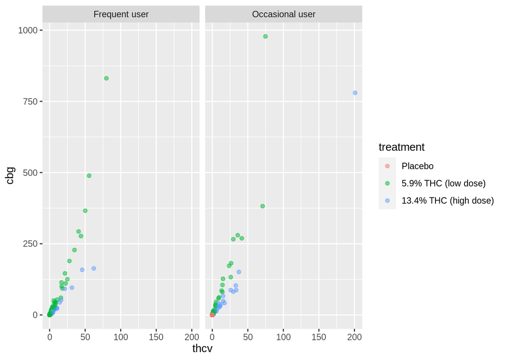

```r
ggplot(data = OF,
       aes(y = cbg, x = thcv, color = treatment)) +
  geom_point(alpha = 0.5) +
  facet_wrap(~group)
```

## Analysis

### Data Analysis

### Results

### Discussion

## Conclusion